# Time Series: The Fundamentals

# Objectives

- Discuss basic motivations for time series analysis.
- Introduce analysis assumptions for financial data.
- Define terminologies: market stochasticity, stationarity, etc.
- Set up general notation of relevant statistics.
- Introduce the White Noise process.

# What is a Time Series?

We first look at the time plot for the SPY daily price between 8/27/2018 and 8/27/2022.

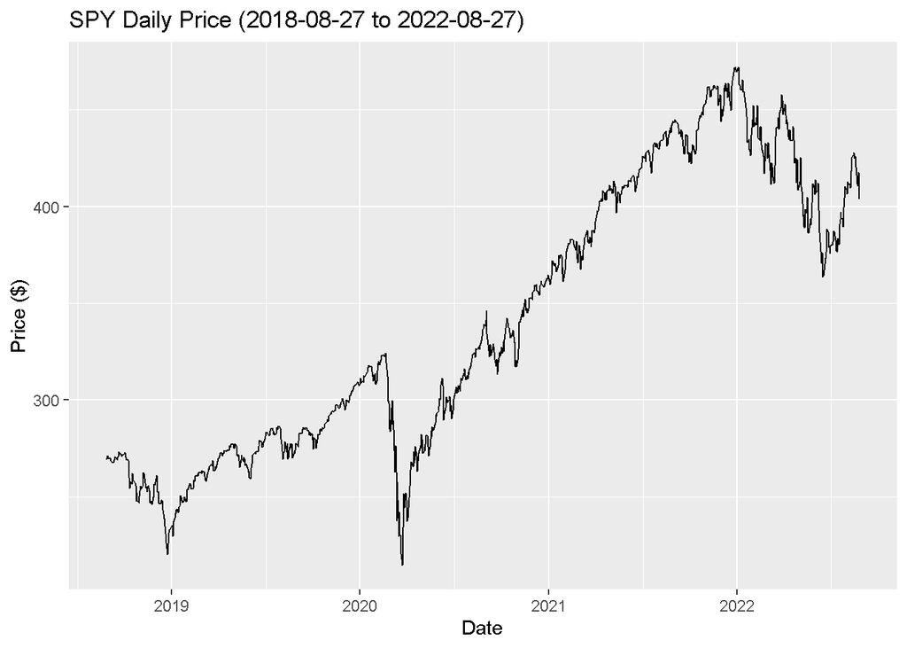

Let’s also look at the time plot for the weekly log returns of the 20+ Year Treasury Bond ETF over the same time period.

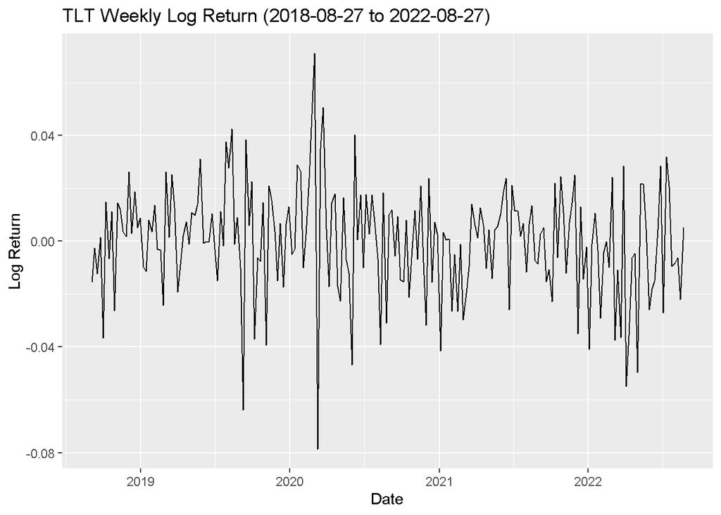

Monthly Consumer Price Index (CPI) is often used as a predictor in econometrics and business forecasts, and resonates with the economic conditions from expansion to recession.

[figure not shown]

A company’s quarterly earnings report is one of the utmost important evidence for its financial stability. Its evolution throughout time is what executives and investors look to at before making any financial decisions.

[figure not shown]

For any data set, there are two assumptions that must be made. First, we assume that the price we receive is a collection of data points with constant time intervals. You may determine the interval depending on the type of trader you are. This is summarized in the table below.

| Day Trader | Swing Trader | Investor |
| --- | --- | --- |
| 15-minute | Daily | Quarterly |
| 60-minute | Weekly | Yearly |
| 240-minute | Monthly | 5-Yearly |

# Market Stochasticity

Second, we assume the price movements in the market are random, and hence follow a stochastic process. They are time-dependent and exhibits trend and seasonal patterns.

Typically, we can easily see that on a daily chart, the stock price is either in an uptrend, sideways, or downtrend pattern. The daily price of SPY shows exactly this. Uptrend from 2019-2020, but then COVID-19 hits, inducing a few months of setback before the price starts to recover. It then moves sideways in the second half of 2020 before continuing the uptrend. Since the beginning of 2022, SPY has been on an overall downtrend.

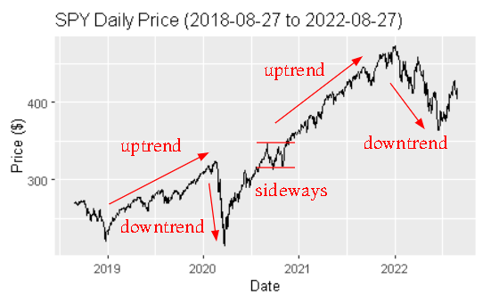

We can also observe the seasonal effects on price due to weekends and holidays. For example, Ester in April or Thanksgiving in the November may be what’s contributing to the upside return extension for SPY.

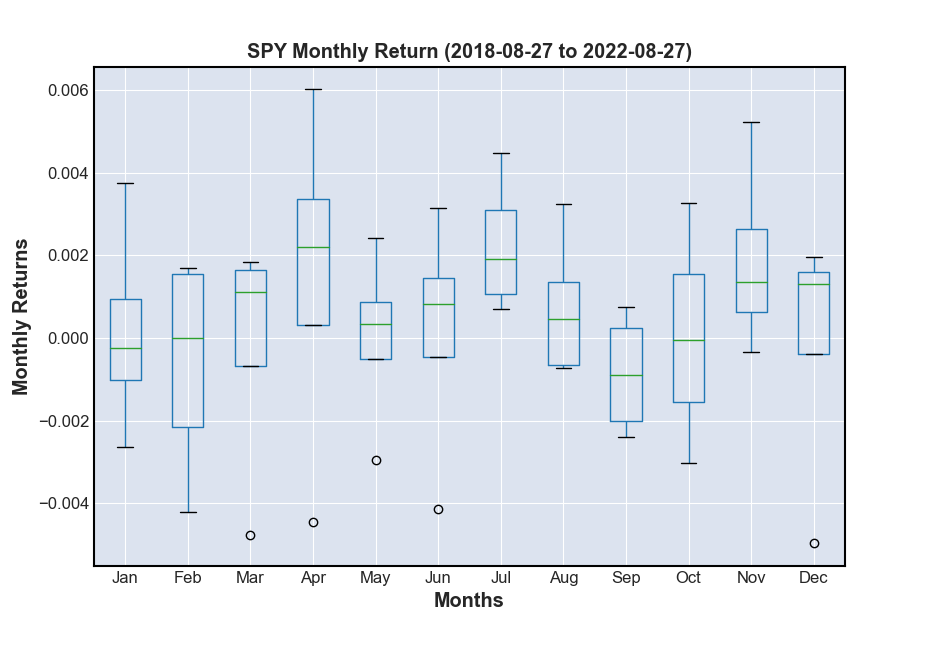

Research shows that one of the most useful methods of obtaining parsimony in a time series model is to assume some form of stationarity. We will discuss this next.

# Stationarity Assumptions

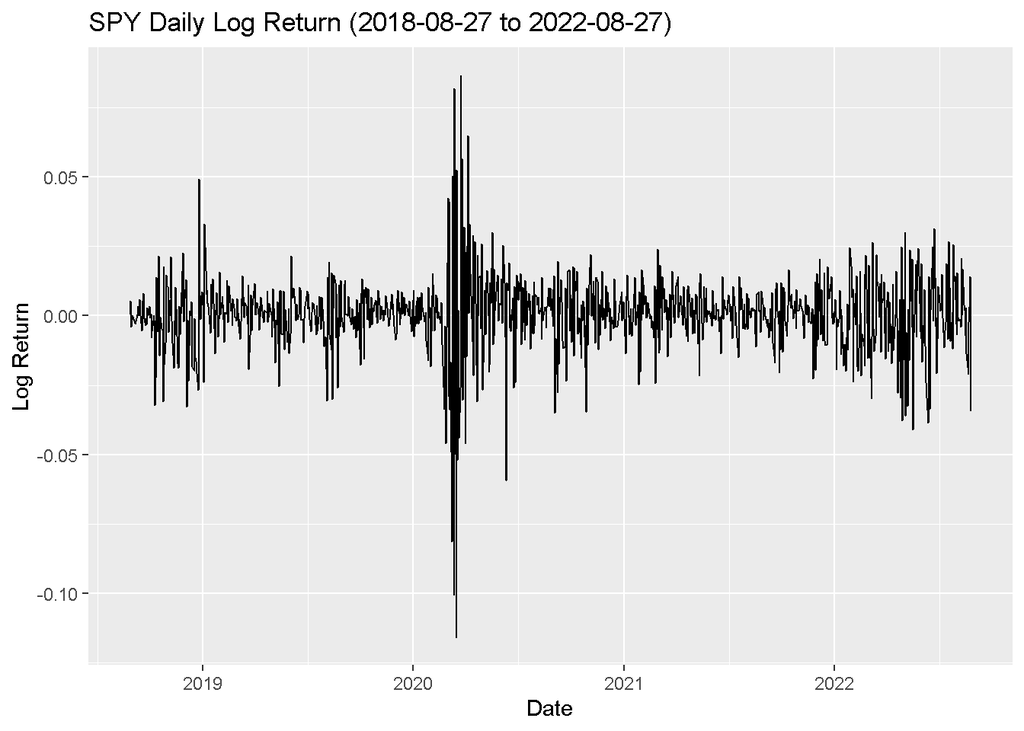

## Weak Stationarity Assumption

## Weak Stationarity & The Principle of Parsimony

## Differencing Parameter d

```r
lr_spy_arima0 <- auto.arima(lr_spy, d=0, stepwise = FALSE, approximation = FALSE, ic = 'bic', trace = TRUE)
```

```
##
##  ARIMA(0,0,0) with zero mean     : -5726.005
##  ARIMA(0,0,0) with non-zero mean : -5719.911
##  ARIMA(0,0,1) with zero mean     : -5746.193
##  ARIMA(0,0,1) with non-zero mean : -5740.463
##  ARIMA(0,0,2) with zero mean     : -5762.365
##  ARIMA(0,0,2) with non-zero mean : -5756.328
##  ARIMA(0,0,3) with zero mean     : -5756.708
##  ARIMA(0,0,3) with non-zero mean : -5750.753
##  ARIMA(0,0,4) with zero mean     : -5750.612
##  ARIMA(0,0,4) with non-zero mean : -5744.719
##  ARIMA(0,0,5) with zero mean     : -5743.731
##  ARIMA(0,0,5) with non-zero mean : -5737.852
##  ARIMA(1,0,0) with zero mean     : -5753.429
##  ARIMA(1,0,0) with non-zero mean : -5747.737
##  ARIMA(1,0,1) with zero mean     : -5754.406
##  ARIMA(1,0,1) with non-zero mean : -5748.634
##  ARIMA(1,0,2) with zero mean     : -5756.349
##  ARIMA(1,0,2) with non-zero mean : -5750.358
##  ARIMA(1,0,3) with zero mean     : -5750.631
##  ARIMA(1,0,3) with non-zero mean : -5744.76
##  ARIMA(1,0,4) with zero mean     : -5776.968
##  ARIMA(1,0,4) with non-zero mean : -5771.081
##  ARIMA(2,0,0) with zero mean     : -5760.756
##  ARIMA(2,0,0) with non-zero mean : -5754.798
##  ARIMA(2,0,1) with zero mean     : -5754.183
##  ARIMA(2,0,1) with non-zero mean : -5748.199
##  ARIMA(2,0,2) with zero mean     : -5749.91
##  ARIMA(2,0,2) with non-zero mean : -5743.95
##  ARIMA(2,0,3) with zero mean     : -5744.101
##  ARIMA(2,0,3) with non-zero mean : -5738.246
##  ARIMA(3,0,0) with zero mean     : -5754.637
##  ARIMA(3,0,0) with non-zero mean : -5748.627
##  ARIMA(3,0,1) with zero mean     : -5793.66
##  ARIMA(3,0,1) with non-zero mean : -5787.603
##  ARIMA(3,0,2) with zero mean     : -5746.071
##  ARIMA(3,0,2) with non-zero mean : -5740.33
##  ARIMA(4,0,0) with zero mean     : -5754.439
##  ARIMA(4,0,0) with non-zero mean : -5748.596
##  ARIMA(4,0,1) with zero mean     : -5795.144
##  ARIMA(4,0,1) with non-zero mean : -5789.266
##  ARIMA(5,0,0) with zero mean     : -5749.497
##  ARIMA(5,0,0) with non-zero mean : -5743.556
##
##
##
##  Best model: ARIMA(4,0,1) with zero mean
```

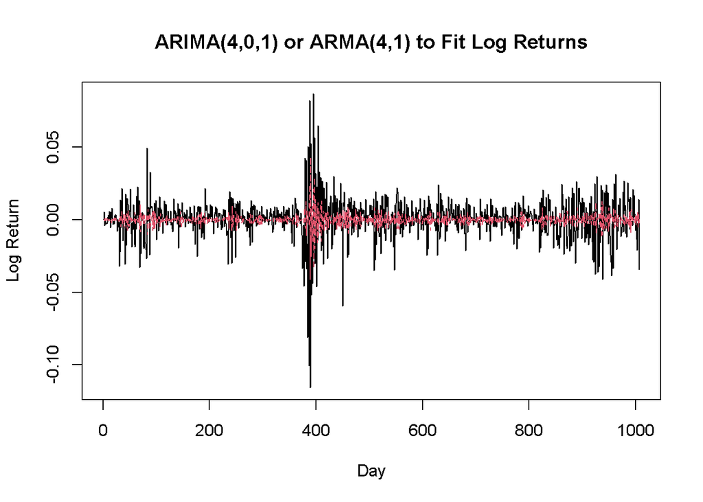

```r
ts.plot(lr_spy, main = 'ARIMA(4,0,1) or ARMA(4,1) to Fit Log Returns', ylab = 'Log Return', xlab = 'Day')
points(fitted(lr_spy_arima0), type = "l", col = 2, lty = 2)
```

```r
lr_spy_arima1 <- auto.arima(lr_spy, d=1, stepwise = FALSE, approximation = FALSE, ic = 'bic', trace = TRUE)
```

```
##
##  ARIMA(0,1,0)                    : -4855.793
##  ARIMA(0,1,0) with drift         : -4848.882
##  ARIMA(0,1,1)                    : Inf
##  ARIMA(0,1,1) with drift         : Inf
##  ARIMA(0,1,2)                    : Inf
##  ARIMA(0,1,2) with drift         : Inf
##  ARIMA(0,1,3)                    : Inf
##  ARIMA(0,1,3) with drift         : Inf
##  ARIMA(0,1,4)                    : Inf
##  ARIMA(0,1,4) with drift         : Inf
##  ARIMA(0,1,5)                    : Inf
##  ARIMA(0,1,5) with drift         : Inf
##  ARIMA(1,1,0)                    : -5376.753
##  ARIMA(1,1,0) with drift         : -5369.843
##  ARIMA(1,1,1)                    : Inf
##  ARIMA(1,1,1) with drift         : Inf
##  ARIMA(1,1,2)                    : Inf
##  ARIMA(1,1,2) with drift         : Inf
##  ARIMA(1,1,3)                    : Inf
##  ARIMA(1,1,3) with drift         : Inf
##  ARIMA(1,1,4)                    : Inf
##  ARIMA(1,1,4) with drift         : Inf
##  ARIMA(2,1,0)                    : -5490.445
##  ARIMA(2,1,0) with drift         : -5483.534
##  ARIMA(2,1,1)                    : Inf
##  ARIMA(2,1,1) with drift         : Inf
##  ARIMA(2,1,2)                    : Inf
##  ARIMA(2,1,2) with drift         : Inf
##  ARIMA(2,1,3)                    : Inf
##  ARIMA(2,1,3) with drift         : Inf
##  ARIMA(3,1,0)                    : -5512.191
##  ARIMA(3,1,0) with drift         : -5505.28
##  ARIMA(3,1,1)                    : Inf
##  ARIMA(3,1,1) with drift         : Inf
##  ARIMA(3,1,2)                    : Inf
##  ARIMA(3,1,2) with drift         : Inf
##  ARIMA(4,1,0)                    : -5569.469
##  ARIMA(4,1,0) with drift         : -5562.559
##  ARIMA(4,1,1)                    : Inf
##  ARIMA(4,1,1) with drift         : Inf
##  ARIMA(5,1,0)                    : -5565.687
##  ARIMA(5,1,0) with drift         : -5558.777
##
##
##
##  Best model: ARIMA(4,1,0)
```

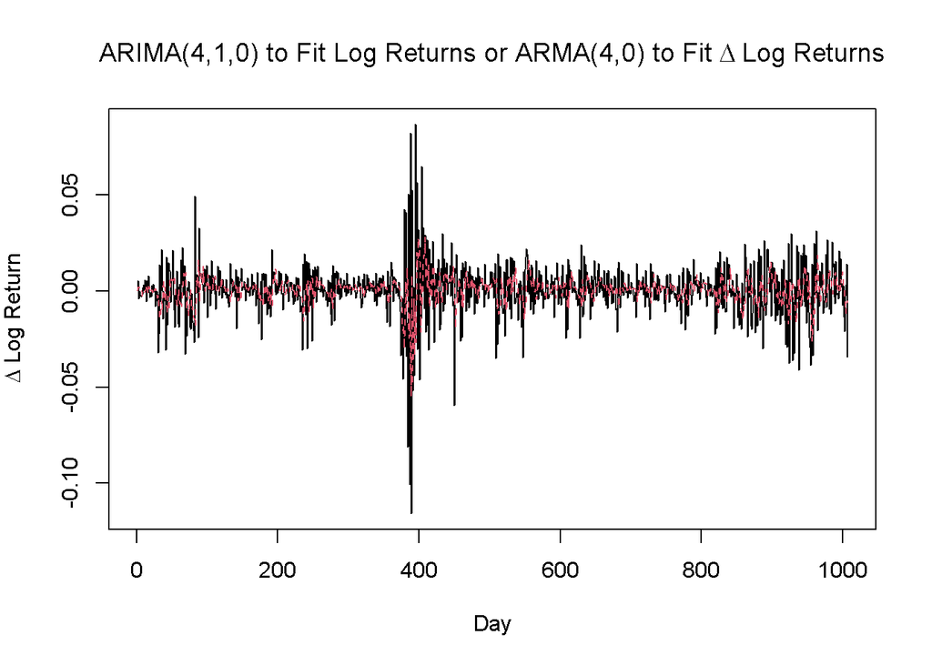

```r
ts.plot(lr_spy, main = expression("ARIMA(4,1,0) to Fit Log Returns or ARMA(4,0) to Fit"~Delta~"Log Returns"), ylab = expression(Delta~'Log Return'), xlab = 'Day')
points(fitted(lr_spy_arima1), type = "l", col = 2, lty = 2)
```

```r
lr_spy_arima2 <- auto.arima(lr_spy, d=2, stepwise = FALSE, approximation = FALSE, ic = 'bic', trace = TRUE)
```

```
##
##  ARIMA(0,2,0)                    : -3659.208
##  ARIMA(0,2,1)                    : Inf
##  ARIMA(0,2,2)                    : Inf
##  ARIMA(0,2,3)                    : Inf
##  ARIMA(0,2,4)                    : Inf
##  ARIMA(0,2,5)                    : Inf
##  ARIMA(1,2,0)                    : -4513.279
##  ARIMA(1,2,1)                    : Inf
##  ARIMA(1,2,2)                    : Inf
##  ARIMA(1,2,3)                    : Inf
##  ARIMA(1,2,4)                    : Inf
##  ARIMA(2,2,0)                    : -4881.94
##  ARIMA(2,2,1)                    : Inf
##  ARIMA(2,2,2)                    : Inf
##  ARIMA(2,2,3)                    : Inf
##  ARIMA(3,2,0)                    : -4992.499
##  ARIMA(3,2,1)                    : Inf
##  ARIMA(3,2,2)                    : Inf
##  ARIMA(4,2,0)                    : -5164.974
##  ARIMA(4,2,1)                    : Inf
##  ARIMA(5,2,0)                    : -5170.894
##
##
##
##  Best model: ARIMA(5,2,0)
```

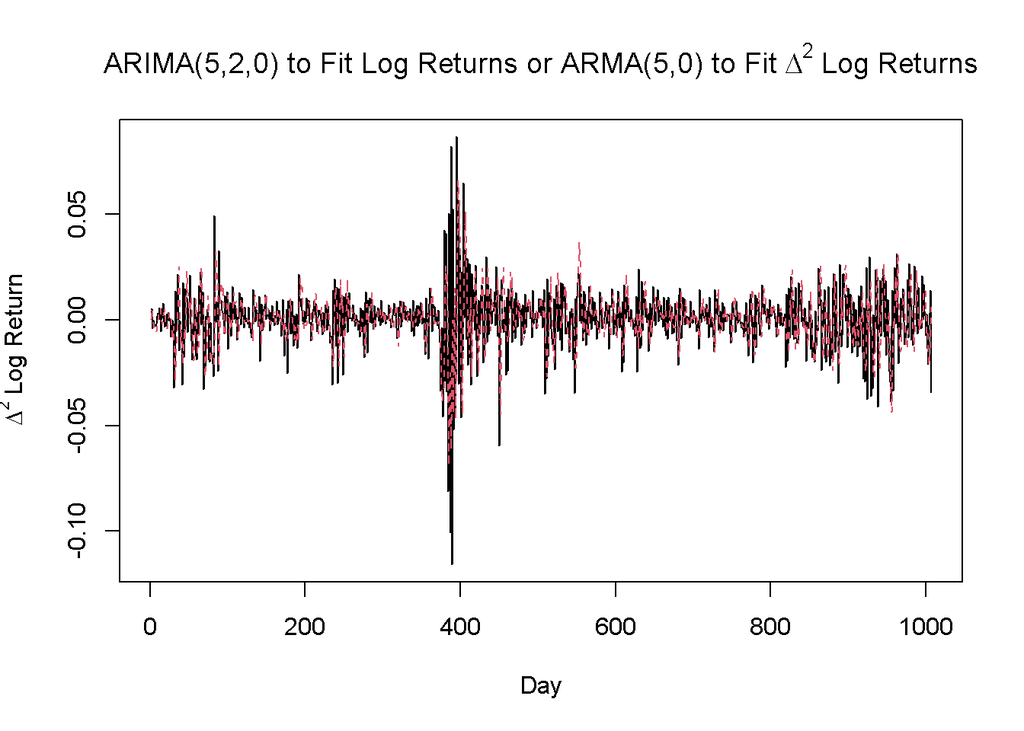

```r
ts.plot(lr_spy, main = expression("ARIMA(5,2,0) to Fit Log Returns or ARMA(5,0) to Fit"~Delta^2~"Log Returns"), ylab = expression(Delta^2~'Log Return'), xlab = 'Day')
points(fitted(lr_spy_arima2), type = "l", col = 2, lty = 2)
```